# TERRE GRS: Replication of hits

The manuscript “A Parkinson’s disease genetic risk score associates with blood DNAm on chromosome 17” explores how a genetic risk score (GRS) for Parkinson’s disease (PD) associates with blood DNA methylation in the TERRE study of French agricultural workers, and evaluates GRS associations with DNAm in each sex as well as their sensitivity to non-genetic factors. This was originally spearheaded by Will Casazza and was posted as a pre-print on medRxiv in 2023. The current revision (2024, led by Sam Schaffner) aims to address previous reviewer feedback and prepare the manuscript for re-submission.

In this script, the effect sizes of hits discovered in the TERRE sample will be examined in the DIGPD sample, as will the PRS distribution in DIGPD. CpGs in the MAPT/KANSL1 region previously reported to be mQTLs for PD and other neurodegenerative disorders will also be examined in TERRE. Finally, TERRE GRS hits will be compared with PD-associated hits in TERRE and SGPD, using data from the CMR paper.

Last updated June 20, 2025 by Samantha Schaffner: Checking for case-control DNAm differences for replicated CpGs

Based on code by Will Casazza

# Comparison of effect sizes between TERRE and DIGPD

## Cross-sex sample

### Combined cases and controls, adjusted for PD status

```r
terre_meta <- read.csv("~/PD_GRS/meta_for_GRS_EWAS.csv")
terre_x_sex <- read.csv("~/PD_GRS/EWAS_TERRE/EWAS_GRS_cross_sex_hits.csv")

digpd_x_sex <- read.csv("~/PD_GRS/EWAS_DIGPD/DIGPD_EWAS_GRS_cross_sex.csv")

# join data together to compare effects and p-values from each analysis: M
digpd_sub <- digpd_x_sex[,c("TargetID","delta_M","adj.P.Val", "P.Value")]
colnames(digpd_sub) <- c("TargetID", "delta_M_DIGPD", "adj.P.Val.DIGPD", "P.Value.DIGPD")
terre_sub <- terre_x_sex[,c("TargetID","delta_M","adj.P.Val", "P.Value")]
colnames(terre_sub) <- c("TargetID", "delta_M_TERRE", "adj.P.Val.TERRE", "P.Value.TERRE")
combine <- left_join(terre_sub, digpd_sub, by="TargetID")
combine <- combine[complete.cases(combine$delta_M_DIGPD),] #one NA in DIGPD (a TERRE hit not in DIGPD data)
max(c(combine$delta_M_TERRE, combine$delta_M_DIGPD)) #193.8127
min(c(combine$delta_M_TERRE, combine$delta_M_DIGPD)) #-176.0213

png("~/PD_GRS/EWAS_DIGPD/TERRE_cross_sex_in_DIGPD.png", width=200, height=225)
ggplot(combine, aes(x=delta_M_TERRE, y=delta_M_DIGPD)) + geom_point() + geom_smooth(method="lm", col="grey") + theme_bw() + xlab("TERRE adjusted delta M") + ylab("DIG-PD adjusted delta M") + xlim(c(-200,200)) + ylim(c(-200,200)) + ggtitle("TERRE cross-sex hits \nin DIG-PD") + stat_cor(label.y=150)
dev.off()

### Check how many CpGs have delta M > 1.5 and nominal p < 0.05 in DIGPD, in the same direction as TERRE
combine$direction <- (sign(combine$delta_M_TERRE)==sign(combine$delta_M_DIGPD))
combine$threshold_M <- (abs(combine$delta_M_DIGPD)>=1.5)
combine$nom_p <- (combine$P.Value.DIGPD<=0.05)

summary(combine[,c("direction","threshold_M","nom_p")])
# direction       threshold_M      nom_p
# Mode :logical   Mode:logical   Mode :logical
# FALSE:1         TRUE:23        FALSE:2
# TRUE :22                       TRUE :21

table(combine$direction, combine$nom_p)
#        FALSE TRUE
#  FALSE     1    0
#  TRUE      1   21

write.csv(combine, file="~/PD_GRS/TERRE_cross_sex_in_DIGPD_M.csv", row.names=F)

# join data together to compare effects and p-values from each analysis: B
digpd_sub <- digpd_x_sex[,c("TargetID","adjDB","adj.P.Val", "P.Value")]
colnames(digpd_sub) <- c("TargetID", "delta_B_DIGPD", "adj.P.Val.DIGPD", "P.Value.DIGPD")
terre_sub <- terre_x_sex[,c("TargetID","adjDB","adj.P.Val", "P.Value")]
colnames(terre_sub) <- c("TargetID", "delta_B_TERRE", "adj.P.Val.TERRE", "P.Value.TERRE")
combine <- left_join(terre_sub, digpd_sub, by="TargetID")
combine <- combine[complete.cases(combine$delta_B_DIGPD),] #one NA in DIGPD (a TERRE hit not in DIGPD data)
max(abs(c(combine$delta_B_TERRE, combine$delta_B_DIGPD))) #0.8531281
min(abs(c(combine$delta_B_TERRE, combine$delta_B_DIGPD))) #0.01700614

png("~/PD_GRS/EWAS_DIGPD/TERRE_cross_sex_in_DIGPD_B.png", width=200, height=225)
ggplot(combine, aes(x=delta_B_TERRE, y=delta_B_DIGPD)) + geom_point() + geom_smooth(method="lm", col="grey") + theme_bw() + xlab("TERRE adjusted delta beta") + ylab("DIG-PD adjusted delta beta") + xlim(c(-1,1)) + ylim(c(-1,1)) + ggtitle("TERRE cross-sex hits \nin DIG-PD") + stat_cor(label.y=0.8)
dev.off()

### Check how many CpGs have delta M > 1.5 and nominal p < 0.05 in DIGPD, in the same direction as TERRE
combine$direction <- (sign(combine$delta_B_TERRE)==sign(combine$delta_B_DIGPD))
combine$threshold_B <- (abs(combine$delta_B_DIGPD)>=0.03)
combine$nom_p <- (combine$P.Value.DIGPD<=0.05)
combine$adj_p <- (combine$adj.P.Val.DIGPD<=0.05)

summary(combine[,c("direction","threshold_B","nom_p")])
# direction       threshold_B       nom_p
# Mode :logical   Mode :logical   Mode :logical
# FALSE:12        FALSE:2         FALSE:2
# TRUE :11        TRUE :21        TRUE :21

table(combine$direction, combine$nom_p)
#        FALSE TRUE
#  FALSE     2   10
#  TRUE      0   11

table(combine$direction, combine$adj_p)
#        FALSE TRUE
#  FALSE     7    5
#  TRUE      6    5

write.csv(combine, file="~/PD_GRS/TERRE_cross_sex_in_DIGPD_B.csv", row.names=F)
```

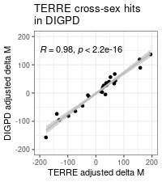

Comparison of cross-sex effect sizes between samples

### Checking case-control DNAm differences for replicated CpGs

Added June 20, 2025.

#### In TERRE

```r
############### EWAS for PD status in TERRE
meta <- read.csv("~/PD_GRS/meta_geno_DNAm_PCs.csv")
load("~/SHARE_DECIPHER/processed_DNAm_data/2022/TERRE_processed_2022/1-TERRE_RG_filtered.RData")
mvals <- getM(PD_RG_filtered)

## Preparing data
# match meta data and M-values
meta <- meta[complete.cases(meta$CTP_PC1),]
mvals <- mvals[,match(meta$patient, colnames(mvals))]
all(colnames(mvals)==meta$patient) #TRUE

# subset meta data to relevant columns and re-format
meta_sub <- meta[,c("patient","SCORE1_AVG","PD","age","sex","geno_V3","geno_V4","geno_V5","CTP_PC1","CTP_PC2","CTP_PC3","CTP_PC4","CTP_PC5","CTP_PC6","smoking","pesticides","head_trauma","alcohol1","levodopa","agonist","plate","SentrixPosition_A")]
meta_sub$PD <- as.factor(meta_sub$PD)
meta_sub$sex <- as.factor(meta_sub$sex)
meta_sub$smoking <- as.factor(meta_sub$smoking)
meta_sub$pesticides <- as.factor(meta_sub$pesticides)
meta_sub$head_trauma <- as.factor(meta_sub$head_trauma)
meta_sub$alcohol1 <- as.factor(meta_sub$alcohol1)
meta_sub$levodopa <- as.factor(meta_sub$levodopa)
meta_sub$plate <- as.factor(meta_sub$plate)
meta_sub$SentrixPosition_A <- as.factor(meta_sub$SentrixPosition_A)

## Variance inflation factor
# check for one CpG (result is the same as when applied to all CpGs and averaged)
vif(lm(mvals[1,] ~ meta_sub$PD + meta_sub$age + meta_sub$sex + meta_sub$geno_V3 + meta_sub$geno_V4 + meta_sub$geno_V5 + meta_sub$CTP_PC1 + meta_sub$CTP_PC2 + meta_sub$CTP_PC3 + meta_sub$CTP_PC4 + meta_sub$CTP_PC5 + meta_sub$CTP_PC6 + meta_sub$plate + meta_sub$SentrixPosition_A))[,3]
#               meta_sub$PD               meta_sub$age               meta_sub$sex           meta_sub$geno_V3           meta_sub$geno_V4
#                  1.050354                   1.104589                   1.541213                   1.081690                   1.098078
#          meta_sub$geno_V5           meta_sub$CTP_PC1           meta_sub$CTP_PC2           meta_sub$CTP_PC3           meta_sub$CTP_PC4
#                  1.060049                   1.096171                   1.130350                   1.313995                   1.141742
#          meta_sub$CTP_PC5           meta_sub$CTP_PC6             meta_sub$plate meta_sub$SentrixPosition_A
#                  1.243462                   1.159639                   1.134204                   1.050336

## Q-Q plot
pvals <- sapply(1:nrow(mvals), function(x) {
  coef(summary(lm(mvals[x,] ~ meta_sub$PD + meta_sub$age + meta_sub$sex + meta_sub$geno_V3 + meta_sub$geno_V4 + meta_sub$geno_V5 + meta_sub$CTP_PC1 + meta_sub$CTP_PC2 + meta_sub$CTP_PC3 + meta_sub$CTP_PC4 + meta_sub$CTP_PC5 + meta_sub$CTP_PC6 + meta_sub$plate + meta_sub$SentrixPosition_A)))[2,4]
   })
qqunif.plot(pvals, title="PD EWAS Model")

## Q-Q plot: in females only
#meta_F <- meta_sub[meta_sub$sex=="F",]
#mvals_F <- mvals[,match(meta_F$patient, colnames(mvals))]
#pvals_F <- sapply(1:nrow(mvals_F), function(x) {
#  coef(summary(lm(mvals_F[x,] ~ meta_F$PD + meta_F$age + meta_F$geno_V3 + meta_F$geno_V4 + meta_F$geno_V5 + meta_F$CTP_PC1 + #meta_F$CTP_PC2 + meta_F$CTP_PC3 + meta_F$CTP_PC4 + meta_F$CTP_PC5 + meta_F$CTP_PC6 + meta_F$plate + meta_F$SentrixPosition_A)))[2,4]
#   })
#qqunif.plot(pvals_F, title="PD EWAS Model: Females")

## Q-Q plot: in males only
#meta_M <- meta_sub[meta_sub$sex=="M",]
#mvals_M <- mvals[,match(meta_M$patient, colnames(mvals))]
#pvals_M <- sapply(1:nrow(mvals_M), function(x) {
#  coef(summary(lm(mvals_M[x,] ~ meta_M$PD + meta_M$age + meta_M$geno_V3 + meta_M$geno_V4 + meta_M$geno_V5 + meta_M$CTP_PC1 + meta_M$CTP_PC2 + meta_M$CTP_PC3 + meta_M$CTP_PC4 + meta_M$CTP_PC5 + meta_M$CTP_PC6 + meta_M$plate + meta_M$SentrixPosition_A)))[2,4]
#   })
#qqunif.plot(pvals_M, title="PD EWAS Model: Males")

## Bias and inflation (based on Z-values)
zvals <- qnorm(pvals)
bacon(zvals)
#...estimated bias: -0.034.
#...estimated inflation: 0.92.

##### EWAS and volcano plot
# set up meta data
na_row <- !apply(meta_sub[, c("PD", "age", "sex", "geno_V3", "geno_V4", "geno_V5", "CTP_PC1", "CTP_PC2", "CTP_PC3", "CTP_PC4", "CTP_PC5", "CTP_PC6", "plate", "SentrixPosition_A")], 1, function(x) any(is.na(x)))
summary(na_row) #no NA's for these covariates
str(meta_sub[,c("PD", "age", "sex", "geno_V3", "geno_V4", "geno_V5", "CTP_PC1", "CTP_PC2", "CTP_PC3", "CTP_PC4", "CTP_PC5", "CTP_PC6", "plate", "SentrixPosition_A")]) #checking format again - good

####### Cross-sex PD EWAS
# limma design matrix and linear model fit
design_prs <- model.matrix(~ 1 + PD + age + sex + geno_V3 + geno_V4 + geno_V5 + CTP_PC1 + CTP_PC2 + CTP_PC3 + CTP_PC4 + CTP_PC5 + CTP_PC6 + plate + SentrixPosition_A, data = meta_sub)
prs_fit <- lmFit(mvals, design_prs)
prs_fit <- eBayes(prs_fit)
# transform adjusted M-values to adjusted beta-values (code from Kruppa et al. 2021)
prs_fit_coef <- prs_fit$coefficients
m0_eff <- prs_fit_coef[, "(Intercept)"] #M-value model intercept
m1_eff <- m0_eff + prs_fit_coef[, "PD1"] #M-value model intercept plus GRS coefficient (delta M)

prs_res <- limma::topTable(prs_fit, coef = 2, number = Inf, genelist=rownames(mvals))
prs_res$adjDB <- m2beta(m1_eff) - m2beta(m0_eff) #transform each adjusted M-value to a beta-value, and subtract intercept beta value from intercept + coefficient beta value to obtain the adjusted delta beta
nrow(prs_res[abs(prs_res$adjDB)>=0.03 & prs_res$adj.P.Val<=0.05,]) #0

#colour and label the 11 replicated CpGs for the volcano plot
repl_cpgs <- read.csv("~/PD_GRS/TERRE_cross_sex_in_DIGPD_B.csv")
repl_cpgs <- repl_cpgs[repl_cpgs$direction==TRUE,]
prs_res$repl <- (prs_res$ID %in% repl_cpgs$TargetID)
write.csv(prs_res, file="~/PD_GRS/EWAS_TERRE/EWAS_PD_cross_sex.csv", row.names=F)

# are the replicated CpGs in any CMRs that were DM in the 2024 npj PD paper?
terre_cmrs_f <- read.csv("~/PD_CMRs_GxE/2-EWAS_CMRs/TERRE/rlm_F_hits_BH0.05_adjDB0.03_042023.csv")
terre_cmrs_m <- read.csv("~/PD_CMRs_GxE/2-EWAS_CMRs/TERRE/rlm_M_hits_BH0.05_adjDB0.03_042023.csv")
terre_cmrs_f$sex <- "F"
terre_cmrs_m$sex <- "M"
terre_cmrs <- rbind(terre_cmrs_f, terre_cmrs_m)
repl_cpgs_cmrs <- sapply(1:nrow(repl_cpgs), function(x){
  if (length(grep(repl_cpgs$TargetID[x],terre_cmrs$cmr))>0){ return(terre_cmrs$cmr) } else { return(NA) }
})
repl_cpgs_cmrs
# [1] NA NA NA NA NA NA NA NA NA NA NA

png("~/PD_GRS/EWAS_TERRE/volcano_PD_repl_CpGs.png", width=300, height=250)
ggplot(prs_res[,c("adjDB","P.Value","repl","ID")], aes(x=adjDB, y=-log10(P.Value), colour=repl)) +
  geom_point(size=1.75) + geom_point(data=prs_res[prs_res$repl==TRUE,c("adjDB","P.Value","repl","ID")], size=1.75, col="red") +
  labs(legend.position = "none") +
  xlab("Adjusted Delta Beta") + ylab("-log10 P-Value") + theme_classic() + scale_color_manual(values=c("gray70","red")) + geom_vline(xintercept=-0.03) + geom_vline(xintercept=0.03) + xlim(c(-0.15,0.15)) + ggtitle("PD Status EWAS: TERRE")
dev.off()

####### Female PD EWAS
# limma design matrix and linear model fit
design_prs <- model.matrix(~ 1 + PD + age + geno_V3 + geno_V4 + geno_V5 + CTP_PC1 + CTP_PC2 + CTP_PC3 + CTP_PC4 + CTP_PC5 + CTP_PC6 + plate + SentrixPosition_A, data = meta_F)
prs_fit <- lmFit(mvals_F, design_prs)
prs_fit <- eBayes(prs_fit)
# transform adjusted M-values to adjusted beta-values (code from Kruppa et al. 2021)
prs_fit_coef <- prs_fit$coefficients
m0_eff <- prs_fit_coef[, "(Intercept)"] #M-value model intercept
m1_eff <- m0_eff + prs_fit_coef[, "PD1"] #M-value model intercept plus GRS coefficient (delta M)

prs_res <- limma::topTable(prs_fit, coef = 2, number = Inf, genelist=rownames(mvals_F))
prs_res$adjDB <- m2beta(m1_eff) - m2beta(m0_eff) #transform each adjusted M-value to a beta-value, and subtract intercept beta value from intercept + coefficient beta value to obtain the adjusted delta beta
nrow(prs_res[abs(prs_res$adjDB)>=0.03 & prs_res$adj.P.Val<=0.05,]) #0
write.csv(prs_res, file="~/PD_GRS/EWAS_TERRE/EWAS_PD_F.csv", row.names=F)

#colour and label the 11 replicated CpGs for the volcano plot
prs_res$repl <- (prs_res$ID %in% repl_cpgs$TargetID)

png("~/PD_GRS/EWAS_TERRE/volcano_PD_repl_CpGs_F.png", width=300, height=250)
ggplot(prs_res[,c("adjDB","P.Value","repl","ID")], aes(x=adjDB, y=-log10(P.Value), colour=repl)) +
  geom_point(size=1.75) + geom_point(data=prs_res[prs_res$repl==TRUE,c("adjDB","P.Value","repl","ID")], size=1.75, col="red") +
  labs(legend.position = "none") +
  xlab("Adjusted Delta Beta") + ylab("-log10 P-Value") + theme_classic() + scale_color_manual(values=c("gray70","red")) + geom_vline(xintercept=-0.03) + geom_vline(xintercept=0.03) + ggtitle("PD Status EWAS: TERRE Females") + xlim(c(-0.3,0.3))
dev.off()

####### Male PD EWAS
# limma design matrix and linear model fit
design_prs <- model.matrix(~ 1 + PD + age + geno_V3 + geno_V4 + geno_V5 + CTP_PC1 + CTP_PC2 + CTP_PC3 + CTP_PC4 + CTP_PC5 + CTP_PC6 + plate + SentrixPosition_A, data = meta_M)
prs_fit <- lmFit(mvals_M, design_prs)
prs_fit <- eBayes(prs_fit)
# transform adjusted M-values to adjusted beta-values (code from Kruppa et al. 2021)
prs_fit_coef <- prs_fit$coefficients
m0_eff <- prs_fit_coef[, "(Intercept)"] #M-value model intercept
m1_eff <- m0_eff + prs_fit_coef[, "PD1"] #M-value model intercept plus GRS coefficient (delta M)

prs_res <- limma::topTable(prs_fit, coef = 2, number = Inf, genelist=rownames(mvals_M))
prs_res$adjDB <- m2beta(m1_eff) - m2beta(m0_eff) #transform each adjusted M-value to a beta-value, and subtract intercept beta value from intercept + coefficient beta value to obtain the adjusted delta beta
nrow(prs_res[abs(prs_res$adjDB)>=0.03 & prs_res$adj.P.Val<=0.05,]) #0
write.csv(prs_res, file="~/PD_GRS/EWAS_TERRE/EWAS_PD_M.csv", row.names=F)

#colour and label the 11 replicated CpGs for the volcano plot
prs_res$repl <- (prs_res$ID %in% repl_cpgs$TargetID)

png("~/PD_GRS/EWAS_TERRE/volcano_PD_repl_CpGs_M.png", width=300, height=250)
ggplot(prs_res[,c("adjDB","P.Value","repl","ID")], aes(x=adjDB, y=-log10(P.Value), colour=repl)) +
  geom_point(size=1.75) + geom_point(data=prs_res[prs_res$repl==TRUE,c("adjDB","P.Value","repl","ID")], size=1.75, col="red") +
  labs(legend.position = "none") +
  xlab("Adjusted Delta Beta") + ylab("-log10 P-Value") + theme_classic() + scale_color_manual(values=c("gray70","red")) + geom_vline(xintercept=-0.03) + geom_vline(xintercept=0.03) + ggtitle("PD Status EWAS: TERRE Males") + xlim(c(-0.4,0.4))
dev.off()
```

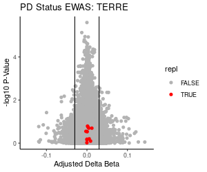

PD Status EWAS, coloured by replicated CpG status

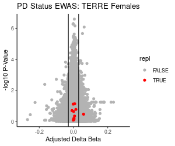

PD Status EWAS in Females, coloured by replicated CpG status

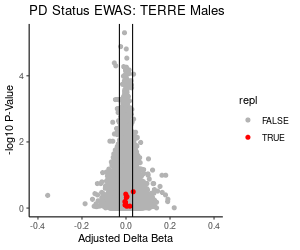

#### In DIG-PD

```r
############### EWAS for PD status in DIGPD
digpd_meta <- read.csv("~/PD_GRS/digpd_meta_geno_DNAm_PCs.csv")
load("~/SHARE_DECIPHER/processed_DNAm_data/2022/DIGPD_processed_2022/1-DIGPD_RG_filtered.RData")
mvals <- getM(DIGPD_RG_filtered)
rm(DIGPD_RG_filtered)

# match meta data and M-values
mvals <- mvals[,match(digpd_meta$Sample_Name, colnames(mvals))]
all(colnames(mvals)==digpd_meta$Sample_Name) #TRUE

# subset meta data to relevant columns and re-format
meta_sub <- digpd_meta[,c("Sample_Name","SCORE1_AVG","PD","Age","reportedSex","GPC1","GPC2","GPC3","CTP_PC1","CTP_PC2","CTP_PC3","CTP_PC4","CTP_PC5","smoking","pesticides","head_trauma","alcohol","levodopa","agonist","plate","SentrixPosition_A")]
str(meta_sub)
meta_sub$PD <- as.factor(meta_sub$PD)
meta_sub$reportedSex <- as.factor(meta_sub$reportedSex)
meta_sub$smoking <- as.factor(meta_sub$smoking)
meta_sub$pesticides <- as.factor(meta_sub$pesticides)
meta_sub$head_trauma <- as.factor(meta_sub$head_trauma)
meta_sub$alcohol <- as.factor(meta_sub$alcohol)
meta_sub$levodopa <- as.factor(meta_sub$levodopa)
meta_sub$plate <- as.factor(meta_sub$plate)
meta_sub$SentrixPosition_A <- as.factor(meta_sub$SentrixPosition_A)

## Variance inflation factor
# check for one CpG (result is the same as when applied to all CpGs and averaged)
vif(lm(mvals[1,] ~ meta_sub$PD + meta_sub$Age + meta_sub$reportedSex + meta_sub$GPC1 + meta_sub$GPC2 + meta_sub$GPC3 + meta_sub$CTP_PC1 + meta_sub$CTP_PC2 + meta_sub$CTP_PC3 + meta_sub$CTP_PC4 + meta_sub$plate + meta_sub$SentrixPosition_A))[,3]
#               meta_sub$PD               meta_sub$Age       meta_sub$reportedSex              meta_sub$GPC1
#                  1.453210                   1.173674                   1.189007                   1.089016
#             meta_sub$GPC2              meta_sub$GPC3           meta_sub$CTP_PC1           meta_sub$CTP_PC2
#                  1.121006                   1.062092                   1.102497                   1.156150
#         meta_sub$CTP_PC3           meta_sub$CTP_PC4             meta_sub$plate meta_sub$SentrixPosition_A
#                  1.099565                   1.046615                   1.052952                   1.084262


## Q-Q plot
#check mvals and replace Inf
min(mvals) #-Inf
min(mvals[mvals>-Inf])
#[1] -16.90111
mvals[mvals==-Inf] <- min(mvals[mvals>-Inf])

pvals <- sapply(1:nrow(mvals), function(x) {
  coef(summary(lm(mvals[x,] ~ meta_sub$PD + meta_sub$Age + meta_sub$reportedSex + meta_sub$GPC1 + meta_sub$GPC2 + meta_sub$GPC3 + meta_sub$CTP_PC1 + meta_sub$CTP_PC2 + meta_sub$CTP_PC3 + meta_sub$CTP_PC4 + meta_sub$plate + meta_sub$SentrixPosition_A)))[2,4]
   })
qqunif.plot(pvals, title="PD EWAS Model")

## Bias and inflation (based on Z-values)
zvals <- qnorm(pvals)
bacon(zvals)
#Bacon-object containing 1 set(s) of 803734 test-statistics.
#...estimated bias: 0.056.
#...estimated inflation: 0.98.

##### EWAS and volcano plot
# set up meta data
na_row <- !apply(meta_sub[, c("SCORE1_AVG", "Age", "reportedSex", "GPC1", "GPC2", "GPC3", "CTP_PC1", "CTP_PC2", "CTP_PC3", "CTP_PC4", "plate", "SentrixPosition_A", "PD")], 1, function(x) any(is.na(x)))
summary(na_row) #no NA's for these covariates
str(meta_sub[,c("SCORE1_AVG", "Age", "reportedSex", "GPC1", "GPC2", "GPC3", "CTP_PC1", "CTP_PC2", "CTP_PC3", "CTP_PC4", "plate", "SentrixPosition_A", "PD")]) #checking format again - good

####### Cross-sex PD EWAS
# limma design matrix and linear model fit
design_prs <- model.matrix(~ 1 + PD + Age + reportedSex + GPC1 + GPC2 + GPC3 + CTP_PC1 + CTP_PC2 + CTP_PC3 + CTP_PC4 + plate + SentrixPosition_A, data = meta_sub)
prs_fit <- lmFit(mvals, design_prs)
prs_fit <- eBayes(prs_fit)
# transform adjusted M-values to adjusted beta-values (code from Kruppa et al. 2021)
prs_fit_coef <- prs_fit$coefficients
m0_eff <- prs_fit_coef[, "(Intercept)"] #M-value model intercept
m1_eff <- m0_eff + prs_fit_coef[, "PD1"] #M-value model intercept plus GRS coefficient (delta M)

prs_res <- limma::topTable(prs_fit, coef = 2, number = Inf, genelist=rownames(mvals))
prs_res$adjDB <- m2beta(m1_eff) - m2beta(m0_eff) #transform each adjusted M-value to a beta-value, and subtract intercept beta value from intercept + coefficient beta value to obtain the adjusted delta beta
nrow(prs_res[abs(prs_res$adjDB)>=0.03 & prs_res$adj.P.Val<=0.05,]) #10

#colour and label the 11 replicated CpGs for the volcano plot
prs_res$repl <- (prs_res$ID %in% repl_cpgs$TargetID)
write.csv(prs_res, file="~/PD_GRS/EWAS_DIGPD/EWAS_PD_cross_sex_DIGPD.csv", row.names=F)

png("~/PD_GRS/EWAS_DIGPD/volcano_PD_repl_CpGs_DIGPD.png", width=300, height=250)
ggplot(prs_res[,c("adjDB","P.Value","repl","ID")], aes(x=adjDB, y=-log10(P.Value), colour=repl)) +
  geom_point(size=1.75) + geom_point(data=prs_res[prs_res$repl==TRUE,c("adjDB","P.Value","repl","ID")], size=1.75, col="red") +
  labs(legend.position = "none") +
  xlab("Adjusted Delta Beta") + ylab("-log10 P-Value") + theme_classic() + scale_color_manual(values=c("gray70","red")) + geom_vline(xintercept=-0.03) + geom_vline(xintercept=0.03) + ggtitle("PD Status EWAS: DIG-PD") + xlim(c(-0.3,0.3))
dev.off()
```

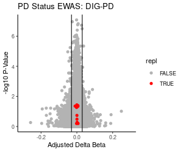

PD Status EWAS, coloured by replicated CpG status

### Controls only

```r
terre_ctrl <- read.csv("~/PD_GRS/EWAS_TERRE/EWAS_GRS_controls_hits.csv")
digpd_ctrl <- read.csv("~/PD_GRS/EWAS_DIGPD/DIGPD_EWAS_GRS_controls.csv")

# join data together to compare effects and p-values from each analysis
digpd_sub <- digpd_ctrl[,c("TargetID","delta_M","adj.P.Val", "P.Value")]
colnames(digpd_sub) <- c("TargetID", "delta_M_DIGPD", "adj.P.Val.DIGPD", "P.Value.DIGPD")
terre_sub <- terre_ctrl[,c("TargetID","delta_M","adj.P.Val", "P.Value")]
colnames(terre_sub) <- c("TargetID", "delta_M_TERRE", "adj.P.Val.TERRE", "P.Value.TERRE")
combine <- left_join(terre_sub, digpd_sub, by="TargetID")
max(c(combine$delta_M_TERRE, combine$delta_M_DIGPD)) #218.4101
min(c(combine$delta_M_TERRE, combine$delta_M_DIGPD)) #-211.3666

png("~/PD_GRS/TERRE_controls_in_DIGPD.png", width=200, height=225)
ggplot(combine, aes(x=delta_M_TERRE, y=delta_M_DIGPD)) + geom_point() + geom_smooth(method="lm", col="grey") + theme_bw() + xlab("TERRE adjusted delta M") + ylab("DIGPD adjusted delta M") + xlim(c(-220,220)) + ylim(c(-220,220)) + ggtitle("TERRE controls hits \nin DIGPD") + stat_cor(label.y=150)
dev.off()

### Check how many CpGs have delta M > 1.5 and nominal p < 0.05 in DIGPD, in the same direction as TERRE
combine$direction <- (sign(combine$delta_M_TERRE)==sign(combine$delta_M_DIGPD))
combine$threshold_M <- (abs(combine$delta_M_DIGPD)>=1.5)
combine$nom_p <- (combine$P.Value.DIGPD<=0.05)

summary(combine[,c("direction","threshold_M","nom_p")])
# direction      threshold_M      nom_p
# Mode:logical   Mode:logical   Mode :logical
# TRUE:14        TRUE:14        FALSE:4
#                               TRUE :10

write.csv(combine, file="~/PD_GRS/TERRE_controls_in_DIGPD.csv", row.names=F)
```

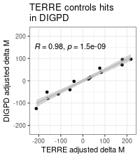

Comparison of controls effect sizes between samples

Effect sizes related to the GRS in cross-sex, control-only analyses are highly correlated in TERRE and DIGPD. 10 of 14 CpGs significant in the TERRE analysis (71%) met nominal p < 0.05 and delta M > 1.5 in DIGPD, in the same direction as in TERRE.

#### Comparing DIGPD case and control effect sizes for TERRE controls hits

As case-control effect sizes were correlated in both cohorts, with controls reaching statistical significance in TERRE and cases reaching statistical significance in DIGPD, I will check if the CpGs associated with the GRS in TERRE controls are also associated with the GRS in DIGPD PD cases.

```r
digpd_case <- read.csv("~/PD_GRS/DIGPD_EWAS_GRS_cases.csv")

# join data together to compare effects and p-values from each analysis
digpd_sub2 <- digpd_case[,c("TargetID","delta_M","adj.P.Val", "P.Value")]
colnames(digpd_sub2) <- c("TargetID", "delta_M_DIGPD_case", "adj.P.Val.DIGPD.case", "P.Value.DIGPD.case")
combine <- left_join(combine, digpd_sub2, by="TargetID")
max(c(combine$delta_M_DIGPD_case, combine$delta_M_DIGPD)) #163.7125
min(c(combine$delta_M_DIGPD_case, combine$delta_M_DIGPD)) #-182.4391

png("~/PD_GRS/TERRE_control_hits_DIGPD_dis_strat.png", width=200, height=225)
ggplot(combine, aes(x=delta_M_DIGPD_case, y=delta_M_DIGPD)) + geom_point() + geom_smooth(method="lm", col="grey") + theme_bw() + xlab("DIGPD cases adjusted delta M") + ylab("DIGPD controls adjusted delta M") + xlim(c(-200,200)) + ylim(c(-200,200)) + ggtitle("TERRE controls hits in \nDIGPD cases and controls") + stat_cor(label.y=150)
dev.off()

### Check how many CpGs have delta M > 1.5 and nominal p < 0.05 in DIGPD cases, in the same direction as TERRE controls
combine$direction_case <- (sign(combine$delta_M_TERRE)==sign(combine$delta_M_DIGPD_case))
combine$threshold_M_case <- (abs(combine$delta_M_DIGPD_case)>=1.5)
combine$nom_p_case <- (combine$P.Value.DIGPD.case<=0.05)

summary(combine[,c("direction_case","threshold_M_case","nom_p_case")])
# direction_case threshold_M_case nom_p_case
# Mode:logical   Mode:logical     Mode :logical
# TRUE:14        TRUE:14          FALSE:2
#                                 TRUE :12

write.csv(combine, file="~/PD_GRS/TERRE_controls_in_DIGPD.csv", row.names=F)
```

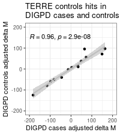

Comparison of TERRE controls effect sizes in DIGPD cases

Effect sizes related to the GRS in TERRE cross-sex, control-only analyses are highly correlated in DIGPD cases and controls. 12 of 14 CpGs significant in the TERRE analysis (86%) met nominal p < 0.05 and delta M > 1.5 in DIGPD cases, in the same direction as in TERRE. Therefore, CpGs picked up in TERRE controls replicated well in both cases and controls from DIGPD, even better in DIGPD PD cases.

# Distribution of GRS in DIGPD

Updated May 17, 2025

### Scale GRS

The GRS should have a mean of 0 and SD of 1 after scaling.

```r
meta <- read.csv("~/PD_GRS/digpd_meta_geno_DNAm_PCs.csv")

# check scaling of PGS: should have mean of 0, SD of 1
mean(meta$SCORE1_AVG) #-0.001045719
sd(meta$SCORE1_AVG) #0.003731846

meta$GRS_scaled <- scale(meta$SCORE1_AVG)
mean(meta$GRS_scaled) #1.188703e-17
sd(meta$GRS_scaled) #1
par(mfrow=c(2,1))
plot(density(meta$SCORE1_AVG), main="GRS prior to scaling", xlim=c(-3,3))
plot(density(meta$GRS_scaled), main="GRS after scaling", xlim=c(-3,3))

write.csv(meta, file="~/PD_GRS/digpd_meta_geno_DNAm_PCs.csv", row.names=F)
```

[figure not shown]

GRS distribution before and after scaling

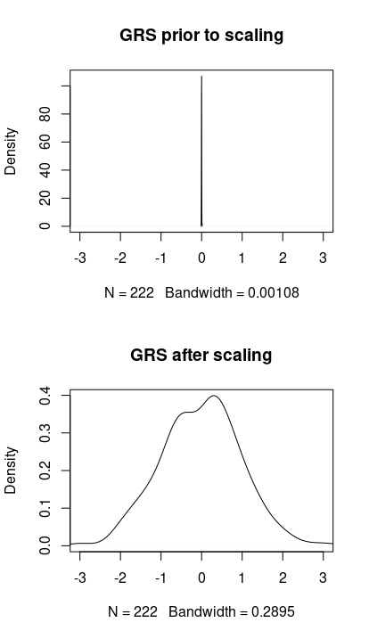

GRS distribution before and after scaling, on the same x-axis

### R2 and h2 calculations

```r
fit1 <- glm(PD ~ GRS_scaled + reportedSex + Age + GPC1 + GPC2 + GPC3, data = meta, family = "binomial")
summary(fit1) #GRS p = 0.0013
fit1_null <- glm(PD ~ reportedSex + Age + GPC1 + GPC2 + GPC3, data = meta, family = "binomial")
summary(fit1_null) #nothing sig
(cross_r2 <- nagelkerke(fit1, null = fit1_null))
#                             Pseudo.R.squared
#McFadden                            0.0365519
#Cox and Snell (ML)                  0.0492481
#Nagelkerke (Cragg and Uhler)        0.0657661

#heritability calculation
lee_h2 <- function(R2O, case_prop, prevalence) {
  K <- prevalence
  P <- case_prop
  thd <- qnorm(1 - K) # Threshold
  z <- dnorm(thd) # Height of the normal density at the threshold
  h2_liab <- R2O * (K * (1 - K) / z^2) * (K * (1 - K) / (P * (1 - P)))
  return(h2_liab)
}

R2 <- cross_r2$Pseudo.R.squared.for.model.vs.null[3]
summary(as.factor(meta$PD))
#  0   1
#112 110
h2 <- lee_h2(R2, 110/222, 5/1000)
R2 #0.0657661
h2 #0.03114314

fit1_male <- glm(PD ~ GRS_scaled + Age + GPC1 + GPC2 + GPC3, data = meta[meta$reportedSex == "M", ], family = "binomial")
summary(fit1_male) #GRS p=0.03
fit1_male_null <- glm(PD ~ Age + GPC1 + GPC2 + GPC3, data = meta[meta$reportedSex == "M", ], family = "binomial")
summary(fit1_male_null) #
(male_r2 <- nagelkerke(fit1_male, null = fit1_male_null))
#                             Pseudo.R.squared
#McFadden                            0.0287700
#Cox and Snell (ML)                  0.0383562
#Nagelkerke (Cragg and Uhler)        0.0516098

R2 <- male_r2$Pseudo.R.squared.for.model.vs.null[3]
summary(as.factor(meta[meta$reportedSex=="M","PD"]))
# 0  1
#66 63
h2 <- lee_h2(R2, 63/129, 5/1000)
R2 #0.0516098
h2 #0.02445075

fit1_female <- glm(PD ~ GRS_scaled + Age + GPC1 + GPC2 + GPC3, data = meta[meta$reportedSex == "F", ], family = "binomial")
summary(fit1_female) #GRS p=0.02
fit1_female_null <- glm(PD ~ Age + GPC1 + GPC2 + GPC3, data = meta[meta$reportedSex == "F", ], family = "binomial")
summary(fit1_female_null) #nothing sig
(female_r2 <- nagelkerke(fit1_female, null = fit1_female_null))
#                             Pseudo.R.squared
#McFadden                            0.0495289
#Cox and Snell (ML)                  0.0644248
#Nagelkerke (Cragg and Uhler)        0.0871381

# liability R2
R2 <- female_r2$Pseudo.R.squared.for.model.vs.null[3]
summary(as.factor(meta[meta$reportedSex=="F","PD"]))
# 0  1
#46 47
h2 <- lee_h2(R2, 47/93, 5/1000)
R2 #0.0871381
h2 #0.04126514
```

### Plotting

```r
r2_labels <- c(
  round(cross_r2$Pseudo.R.squared.for.model.vs.null[3], 4),
  round(male_r2$Pseudo.R.squared.for.model.vs.null[3], 4),
  round(female_r2$Pseudo.R.squared.for.model.vs.null[3], 4)
)
names(r2_labels) <- c("Cross-sex", "Male", "Female")
h2_labels <- c(0.0311, 0.0245,0.0413)
names(h2_labels) <- c("Cross-sex", "Male", "Female")

to_plot <- meta %>%
  mutate(
    PD = ifelse(PD, "CASE", "CONTROL"),
    Sex = ifelse(reportedSex == "M", "Male", "Female")
  ) %>%  mutate(Sex = factor(Sex, levels = c("Cross-sex", "Male", "Female")))
cross_data <- meta %>% mutate(PD = ifelse(PD, "CASE", "CONTROL"))
cross_data$Sex <- "Cross-sex"
to_plot <- rbind(cross_data, to_plot)

to_plot$PD <- factor(to_plot$PD, levels=c("CONTROL","CASE"))
to_plot$Sex <- factor(to_plot$Sex, levels=c("Cross-sex","Male","Female"))

png("~/PD_GRS/DIGPD_prs_plots_by_PD_sex_17May2025.png", width=600, height=500)
ggboxplot(
  to_plot,
  x = "PD",
  y = "GRS_scaled",
  color = "Sex",
  add = "jitter"
) +
  facet_grid(~Sex, labeller = label_bquote(cols = .(as.character(Sex)) ~ ": " ~ .(r2_labels[Sex]) ~ ";" ~ h^2 ~ ": " ~ .(h2_labels[Sex]))) +
  labs(y = "Genetic Risk Score (Scaled)", x = "Parkinson's Diagnosis") +
  scale_color_manual(values = c("gray", "light blue", "pink"))
dev.off()

png("~/PD_GRS/DIGPD_prs_plots_by_sex_17May2025.png", width=300, height=500)
ggboxplot(
  to_plot,
  x = "Sex",
  y = "GRS_scaled",
  color = "Sex",
  add = "jitter"
) +
  stat_compare_means() +

  labs(y = "Genetic Risk Score (Scaled)") +
  scale_color_manual(values = c("Male" = "light blue", "Female" = "pink"))
dev.off()
```

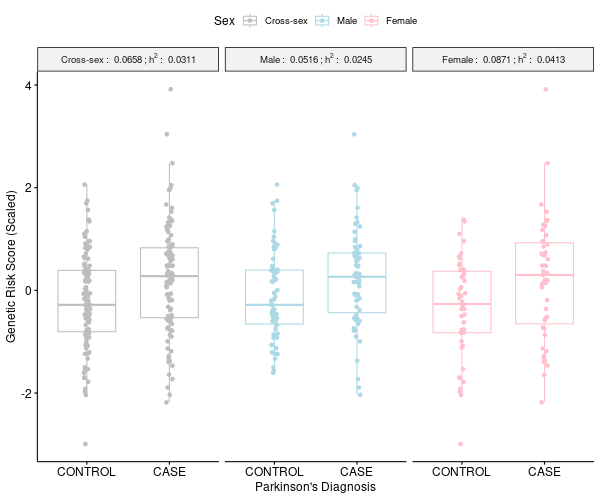

GRS by PD status and sex in DIGPD

PD cases have a greater spread in GRS values than controls. Could this be why EWAS stratified by disease for DIGPD only returns hits for the PD group and not controls?

# Plotting top CpGs from TERRE EWAS

According to GRS.

```r
# get the top 5 CpGs, ranked by adjusted p-value
terre_x_sex <- terre_x_sex %>% arrange(adj.P.Val)
cpgs <- terre_x_sex[1:5,c("TargetID","UCSC_REFGENE_NAME","UCSC_REFGENE_GROUP","CHR","MAPINFO","adj.P.Val","delta_M")]
#    TargetID UCSC_REFGENE_NAME                  UCSC_REFGENE_GROUP CHR  MAPINFO    adj.P.Val    delta_M
#1 cg18228076              MAPT 5'UTR;5'UTR;5'UTR;5'UTR;5'UTR;5'UTR  17 43983362 8.881315e-07  195.26510
#2 cg19832721          KIAA1267                             TSS1500  17 44249866 8.881315e-07  -97.69224
#3 cg12609785                                                        17 43660871 2.725533e-06 -177.98534
#4 cg09860564            KANSL1                      Body;Body;Body  17 44213797 3.121469e-06   69.93698
#5 cg05314706          ARHGAP27                       5'UTR;TSS1500  17 43508250 3.121469e-06  -47.35520

load("~/PD_GRS/TERRE_Mvals.RData")
mvals_sub <- t(mvals[match(cpgs$TargetID, rownames(mvals)),])
all(rownames(mvals_sub)==terre_meta$patient) #TRUE
terre_meta <- cbind(terre_meta, mvals_sub)
terre_meta$PD <- gsub(0, "Control", gsub(1, "Case", terre_meta$PD))

min(mvals_sub) #-5.238008
max(mvals_sub) #4.04658

p1 <- ggplot(terre_meta, aes(x=SCORE1_AVG, y=cg18228076, col=PD)) + geom_point() + geom_smooth(method="lm", stat="smooth", col="grey30") + theme_bw() + ggtitle("cg18228076 \nMAPT 5' UTR") + ylab("M-value") + scale_colour_manual(values=c("black","grey")) + ylim(c(-6,6)) + xlab("Polygenic Risk Score") + theme(legend.position="none")
p2 <- ggplot(terre_meta, aes(x=SCORE1_AVG, y=cg19832721, col=PD)) + geom_point() + geom_smooth(method="lm", stat="smooth", col="grey30") + theme_bw() + ggtitle("cg19832721 \nKIAA1267 TSS1500") + ylab("M-value") + scale_colour_manual(values=c("black","grey")) + ylim(c(-6,6)) + xlab("Polygenic Risk Score") + theme(legend.position="none")
p3 <- ggplot(terre_meta, aes(x=SCORE1_AVG, y=cg12609785, col=PD)) + geom_point() + geom_smooth(method="lm", stat="smooth", col="grey30") + theme_bw() + ggtitle("cg12609785 \nIntergenic") + ylab("M-value") + scale_colour_manual(values=c("black","grey")) + ylim(c(-6,6)) + xlab("Polygenic Risk Score") + theme(legend.position="none")
p4 <- ggplot(terre_meta, aes(x=SCORE1_AVG, y=cg09860564, col=PD)) + geom_point() + geom_smooth(method="lm", stat="smooth", col="grey30") + theme_bw() + ggtitle("cg09860564 \nKANSL1 Body") + ylab("M-value") + scale_colour_manual(values=c("black","grey")) + ylim(c(-6,6)) + xlab("Polygenic Risk Score") + theme(legend.position="none")
p5 <- ggplot(terre_meta, aes(x=SCORE1_AVG, y=cg05314706, col=PD)) + geom_point() + geom_smooth(method="lm", stat="smooth", col="grey30") + theme_bw() + ggtitle("cg05314706 \nARHGAP27 5' UTR/TSS1500") + ylab("M-value") + scale_colour_manual(values=c("black","grey")) + ylim(c(-6,6)) + xlab("Polygenic Risk Score") + theme(legend.position="none")

grid.arrange(p1,p2,p3,p4, nrow=2)
```

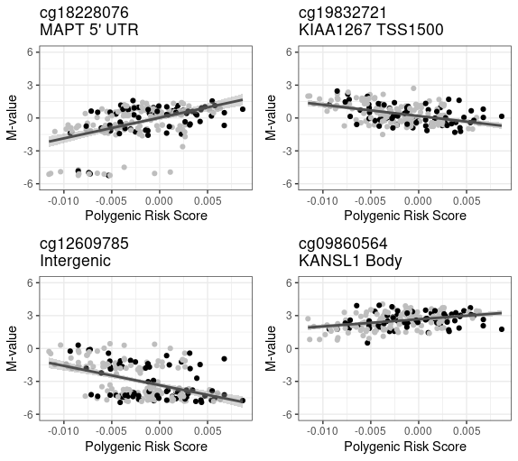

Top 4 CpGs from TERRE cross-sex EWAS

# Examining CpGs identified in other EWAS in TERRE

Li et al., PLoS Genet 2014: Authors did an EWAS in blood for progressive supranuclear palsy (PSP), and found a cluster of associated CpGs in the 17q21.31 region. They also identified cis-mQTL effects in this region, driven by the H1 haplotype.

Ohlei et al., medRxiv 2023: Authors reported mQTLs in blood, buccal, and saliva using datasets of n >1k for each tissue. They conducted MR analyses to identify causal associations between genotype, DNAm, and neurodegenerative disorders. 15 causal CpGs for PD were all in the 17q21 region and were consistent in all 3 tissues.

### Li et al. PSP EWAS

```r
### Li et al. PSP analysis
psp <- read.csv("~/PD_GRS/Li_2014_PSP_EWAS.csv")
psp <- psp %>% arrange(p)

#thresholds: BH-adjusted p < 0.05, DB > 0.1
psp$threshold <- (abs(psp$logFC)>0.1 & psp$p <= 0.05)
summary(psp$threshold) #14 true, matching with article
psp <- psp[psp$threshold==TRUE,]

terre_x_sex_all <- read.csv("~/PD_GRS/EWAS_TERRE/EWAS_GRS_cross_sex.csv")

cpgs <- terre_x_sex_all[terre_x_sex_all$TargetID %in% psp$ID,c("TargetID","UCSC_REFGENE_NAME","UCSC_REFGENE_GROUP","CHR","MAPINFO","adj.P.Val","P.Value", "delta_M")]

#none overlapping with TERRE were examined for mQTLs in the paper - check non-overlapping
psp[-which(psp$ID %in% terre_x_sex_all$TargetID),]
#             ID      logFC          p                Gene CHR Coordinate    Type threshold
#3047 cg03644281 -0.1052885 0.01199518 NFYA;NFYA;LOC221442   6   41068752  Island      TRUE
#3436 cg03428951 -0.1333696 0.01405849             FAM153C   5  177434336 S_Shore      TRUE
#3515 cg25110423 -0.1118670 0.01454182 NFYA;NFYA;LOC221442   6   41068646  Island      TRUE
#4160 cg22968622 -0.1269643 0.01854154                <NA>  17   43663579  Island      TRUE
#cg22968622 had an mQTL

#also check cg19832721, cg19832721 in TERRE
cpgs <- terre_x_sex_all[terre_x_sex_all$TargetID %in% c(psp$ID,"cg19832721","cg19832721"),c("TargetID","UCSC_REFGENE_NAME","UCSC_REFGENE_GROUP","CHR","MAPINFO","adj.P.Val","P.Value", "delta_M")]
cpgs$UCSC_REFGENE_NAME
cpgs$UCSC_REFGENE_NAME <- c("KIAA1267","", "KRTCAP3", "", "", "ARHGAP6", "NFYA", "NFYA", "VSTM2A", "CACNB2", "")

mvals_sub <- t(mvals[match(cpgs$TargetID, rownames(mvals)),])
terre_meta <- terre_meta[,1:22]
all(rownames(mvals_sub)==terre_meta$patient) #TRUE
terre_meta <- cbind(terre_meta, mvals_sub)
terre_meta$PD <- gsub(0, "Control", gsub(1, "Case", terre_meta$PD))

min(mvals_sub) #-5.02833
max(mvals_sub) #6.377419

for (cpg in colnames(terre_meta)[23:33]){
  png(paste("~/PD_GRS/PSP_CpGs/PSP_", cpg, ".png", sep=""), width=200, height=200)
  print(ggplot(terre_meta, aes(x=SCORE1_AVG, y=terre_meta[,cpg], col=PD)) + geom_point() + geom_smooth(method="lm", stat="smooth", col="grey30") + theme_bw() + ggtitle(paste(cpg, "\n", cpgs[cpgs$TargetID==cpg,"UCSC_REFGENE_NAME"], sep="")) + ylab("M-value") + scale_colour_manual(values=c("black","grey")) + ylim(c(-7,7)) + xlab("Polygenic Risk Score") + theme(legend.position="none"))
  dev.off()
}

psp <- psp[match(cpgs$TargetID, psp$ID),]
all(psp$ID==cpgs$TargetID)
cpgs$sign <- (sign(cpgs$delta_M)==sign(psp$logFC))
cpgs$repl <- (cpgs$P.Value<=0.05 & abs(cpgs$delta_M)>1.5 & cpgs$sign==TRUE)
summary(cpgs$repl) #1 TRUE
cpgs[cpgs$repl==TRUE,c("TargetID","UCSC_REFGENE_NAME","CHR","MAPINFO")]
#    TargetID UCSC_REFGENE_NAME CHR  MAPINFO
#3 cg12609785                    17 43660871

source("~/PD_GRS/repl_perm.R")
psp$sign <- FALSE
psp[psp$ID %in% cpgs[cpgs$sign==TRUE,"TargetID"],"sign"] <- TRUE
repl_perm(sig.cpgs=terre_x_sex_all, test.cpgs=psp, n_repl=1) #1000 permutations
#[1] "Permutation P values for enrichment and depletion"
#[1] "Enrichment: 0.515; Depletion 0.839"
```

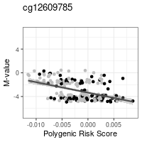

Replicated chr17 intergenic CpG from Li et al. PSP EWAS

cg12609785 (chr17: 43660871) is the only CpG from the PSP study which replicated in TERRE at p < 0.05 and delta M > 1.5.

### Ohlei et al. MR analysis

```r
mr <- read.csv("~/PD_GRS/Ohlei_2023_PD_SMR_blood.csv")
nrow(mr <- mr[mr$P_HEIDI>0.05,]) #114

cpgs <- terre_x_sex_all[terre_x_sex_all$TargetID %in% mr$Probe,c("TargetID","UCSC_REFGENE_NAME","UCSC_REFGENE_GROUP","CHR","MAPINFO","adj.P.Val","P.Value", "delta_M")]

#check which have p-value < 0.05 and delta M > 1.5 in TERRE
#effect direction not reported in Ohlei table
cpgs$repl <- (cpgs$P.Value<=0.05 & abs(cpgs$delta_M)>1.5)
summary(cpgs$repl) #57 TRUE
cpgs <- cpgs[cpgs$repl==TRUE,]
unique(unlist(strsplit(cpgs$UCSC_REFGENE_NAME, split=";")))
# [1] "KIAA1267"       "KANSL1"         "ARHGAP27"       "MAPT"           "CRHR1-IT1"      "MGC57346-CRHR1"
# [7] "LOC100128977"   "LOC100130148"   "SNCA-AS1"       "SNCA"           "SH3D20"         "C17orf69"
#[13] "MGC57346"       "DGKQ"           "MAPT-AS1"

repl_perm(sig.cpgs=terre_x_sex_all, test.cpgs=mr, n_repl=57) #1000 permutations
#[1] "Permutation P values for enrichment and depletion"
#[1] "Enrichment: 0; Depletion 1"

nrow(cpgs_terre_hits <- cpgs[cpgs$TargetID %in% terre_x_sex$TargetID,]) #17
#View(cpgs_terre_hits)

cpgs$UCSC_REFGENE_NAME <- sapply(1:nrow(cpgs), function(x){
  return(unlist(strsplit(cpgs$UCSC_REFGENE_NAME[x], split=";"))[1])
})

mvals_sub <- t(mvals[match(cpgs$TargetID, rownames(mvals)),])
terre_meta <- terre_meta[,1:22]
all(rownames(mvals_sub)==terre_meta$patient) #TRUE
terre_meta <- cbind(terre_meta, mvals_sub)
terre_meta$PD <- gsub(0, "Control", gsub(1, "Case", terre_meta$PD))

min(mvals_sub) #-7.062016
max(mvals_sub) #4.652508

for (cpg in colnames(terre_meta)[23:79]){
  png(paste("~/PD_GRS/MR_CpGs/MR_", cpg, ".png", sep=""), width=200, height=200)
  print(ggplot(terre_meta, aes(x=SCORE1_AVG, y=terre_meta[,cpg], col=PD)) + geom_point() + geom_smooth(method="lm", stat="smooth", col="grey30") + theme_bw() + ggtitle(paste(cpg, "\n", cpgs[cpgs$TargetID==cpg,"UCSC_REFGENE_NAME"], sep="")) + ylab("M-value") + scale_colour_manual(values=c("black","grey")) + ylim(c(-7,7)) + xlab("Polygenic Risk Score") + theme(legend.position="none"))
  dev.off()
}

summary(as.factor(cpgs$UCSC_REFGENE_NAME))
#      ARHGAP27       C17orf69      CRHR1-IT1           DGKQ         KANSL1       KIAA1267           MAPT       MAPT-AS1
#             5              1              1              1             11              2             20              1
#MGC57346-CRHR1         SH3D20           SNCA       SNCA-AS1           NA's
#             3              1              1              2              8
```

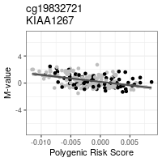

Replicated KIAA1267 CpG from Ohlei et al.

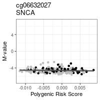

Replicated SNCA CpG from Ohlei et al.

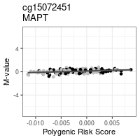

Replicated MAPT CpG from Ohlei et al.